# Predicting Your Chance of Admission for Masters using Linear Regression Model

```r
options(scipen = 9999)
```

# Data Dictionary

- GRE Scores ( out of 340 )
- TOEFL Scores ( out of 120 )
- University Rating ( out of 5 )
- Statement of Purpose and Letter of Recommendation Strength ( out of 5 )
- Undergraduate GPA ( out of 10 )
- Research Experience ( either 0 or 1 )
- Chance of Admit ( ranging from 0 to 1 )

# Setup and Data Import

```r
library(scales)
library(dplyr)
library(GGally)
library(performance)
library(car)
library(MLmetrics)
library(lmtest)
```

```r
admission <- read.csv('AdmissionTrain.csv')
head(admission)
```

```
##   Serial.No. GRE.Score TOEFL.Score University.Rating SOP LOR CGPA Research
## 1          1       337         118                 4 4.5 4.5 9.65        1
## 2          2       324         107                 4 4.0 4.5 8.87        1
## 3          3       316         104                 3 3.0 3.5 8.00        1
## 4          4       322         110                 3 3.5 2.5 8.67        1
## 5          5       314         103                 2 2.0 3.0 8.21        0
## 6          6       330         115                 5 4.5 3.0 9.34        1
##   Chance.of.Admit
## 1            0.92
## 2            0.76
## 3            0.72
## 4            0.80
## 5            0.65
## 6            0.90
```

```r
summary(admission)
```

```
##    Serial.No.      GRE.Score      TOEFL.Score    University.Rating
##  Min.   :  1.0   Min.   :290.0   Min.   : 92.0   Min.   :1.000
##  1st Qu.:100.8   1st Qu.:308.0   1st Qu.:103.0   1st Qu.:2.000
##  Median :200.5   Median :317.0   Median :107.0   Median :3.000
##  Mean   :200.5   Mean   :316.8   Mean   :107.4   Mean   :3.087
##  3rd Qu.:300.2   3rd Qu.:325.0   3rd Qu.:112.0   3rd Qu.:4.000
##  Max.   :400.0   Max.   :340.0   Max.   :120.0   Max.   :5.000
##       SOP           LOR             CGPA          Research
##  Min.   :1.0   Min.   :1.000   Min.   :6.800   Min.   :0.0000
##  1st Qu.:2.5   1st Qu.:3.000   1st Qu.:8.170   1st Qu.:0.0000
##  Median :3.5   Median :3.500   Median :8.610   Median :1.0000
##  Mean   :3.4   Mean   :3.453   Mean   :8.599   Mean   :0.5475
##  3rd Qu.:4.0   3rd Qu.:4.000   3rd Qu.:9.062   3rd Qu.:1.0000
##  Max.   :5.0   Max.   :5.000   Max.   :9.920   Max.   :1.0000
##  Chance.of.Admit
##  Min.   :0.3400
##  1st Qu.:0.6400
##  Median :0.7300
##  Mean   :0.7244
##  3rd Qu.:0.8300
##  Max.   :0.9700
```

# Exploratory Data Analysis

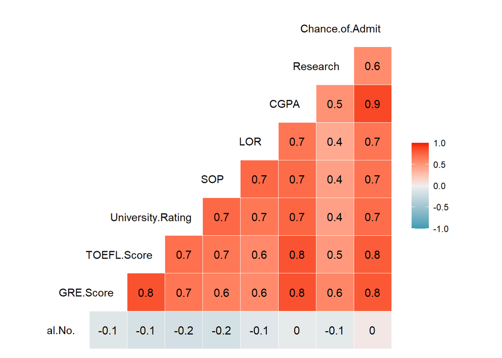

```r
ggcorr(admission, label = T, hjust= 0.9)
```

```r
anyNA(admission)
```

```
## [1] FALSE
```

#Creating Model and Feature Selection

Initial model using all prediction and no prediction

```r
init_model_all <- lm(Chance.of.Admit~., admission)
init_model_none <- lm(Chance.of.Admit~1, admission)
```

Stepwise function using previous model

```r
backstep_model <- step(init_model_all, direction = 'backward')
```

```
## Start:  AIC=-2224.4
## Chance.of.Admit ~ Serial.No. + GRE.Score + TOEFL.Score + University.Rating +
##     SOP + LOR + CGPA + Research
##
##                     Df Sum of Sq    RSS     AIC
## - SOP                1  0.000001 1.4703 -2226.4
## <none>                           1.4703 -2224.4
## - University.Rating  1  0.013613 1.4839 -2222.7
## - GRE.Score          1  0.036819 1.5071 -2216.5
## - Research           1  0.038157 1.5084 -2216.2
## - TOEFL.Score        1  0.045734 1.5160 -2214.2
## - LOR                1  0.061407 1.5317 -2210.0
## - Serial.No.         1  0.124472 1.5948 -2193.9
## - CGPA               1  0.290273 1.7606 -2154.3
##
## Step:  AIC=-2226.4
## Chance.of.Admit ~ Serial.No. + GRE.Score + TOEFL.Score + University.Rating +
##     LOR + CGPA + Research
##
##                     Df Sum of Sq    RSS     AIC
## <none>                           1.4703 -2226.4
## - University.Rating  1  0.014924 1.4852 -2224.4
## - GRE.Score          1  0.037011 1.5073 -2218.5
## - Research           1  0.038427 1.5087 -2218.1
## - TOEFL.Score        1  0.046338 1.5166 -2216.0
## - LOR                1  0.073463 1.5437 -2208.9
## - Serial.No.         1  0.125908 1.5962 -2195.5
## - CGPA               1  0.298134 1.7684 -2154.6
```

```r
forstep_model <- step(init_model_none, direction = 'forward', scope = list(lower = init_model_none, upper = init_model_all))
```

```
## Start:  AIC=-1557.12
## Chance.of.Admit ~ 1
##
##                     Df Sum of Sq    RSS     AIC
## + CGPA               1    6.1885 1.9261 -2130.4
## + GRE.Score          1    5.2273 2.8873 -1968.5
## + TOEFL.Score        1    5.0848 3.0298 -1949.2
## + University.Rating  1    4.1050 4.0096 -1837.1
## + SOP                1    3.7053 4.4094 -1799.1
## + LOR                1    3.6414 4.4732 -1793.3
## + Research           1    2.4833 5.6313 -1701.2
## <none>                           8.1146 -1557.1
## + Serial.No.         1    0.0145 8.1001 -1555.8
##
## Step:  AIC=-2130.38
## Chance.of.Admit ~ CGPA
##
##                     Df Sum of Sq    RSS     AIC
## + GRE.Score          1  0.149590 1.7766 -2160.7
## + TOEFL.Score        1  0.120116 1.8060 -2154.1
## + Research           1  0.106299 1.8198 -2151.1
## + LOR                1  0.105441 1.8207 -2150.9
## + University.Rating  1  0.064574 1.8616 -2142.0
## + Serial.No.         1  0.054897 1.8712 -2139.9
## + SOP                1  0.039553 1.8866 -2136.7
## <none>                           1.9261 -2130.4
##
## Step:  AIC=-2160.72
## Chance.of.Admit ~ CGPA + GRE.Score
##
##                     Df Sum of Sq    RSS     AIC
## + LOR                1  0.105914 1.6706 -2183.3
## + Serial.No.         1  0.077052 1.6995 -2176.4
## + Research           1  0.047158 1.7294 -2169.5
## + University.Rating  1  0.042562 1.7340 -2168.4
## + TOEFL.Score        1  0.034768 1.7418 -2166.6
## + SOP                1  0.033992 1.7426 -2166.4
## <none>                           1.7766 -2160.7
##
## Step:  AIC=-2183.3
```

[output cut: 30 more lines]

```
## Chance.of.Admit ~ CGPA + GRE.Score + LOR + Serial.No. + TOEFL.Score +
##     Research
##
##                     Df Sum of Sq    RSS     AIC
## + University.Rating  1  0.014924 1.4703 -2226.4
## <none>                           1.4852 -2224.4
## + SOP                1  0.001313 1.4839 -2222.7
##
## Step:  AIC=-2226.4
## Chance.of.Admit ~ CGPA + GRE.Score + LOR + Serial.No. + TOEFL.Score +
##     Research + University.Rating
##
##        Df   Sum of Sq    RSS     AIC
## <none>                1.4703 -2226.4
## + SOP   1 0.000001283 1.4703 -2224.4
```

```r
summary(backstep_model)
```

```
##
## Call:
## lm(formula = Chance.of.Admit ~ Serial.No. + GRE.Score + TOEFL.Score +
##     University.Rating + LOR + CGPA + Research, data = admission)
##
## Residuals:
##       Min        1Q    Median        3Q       Max
## -0.233547 -0.026629  0.006155  0.038221  0.140281
##
## Coefficients:
##                      Estimate  Std. Error t value             Pr(>|t|)
## (Intercept)       -1.29378909  0.11967201 -10.811 < 0.0000000000000002 ***
## Serial.No.         0.00015926  0.00002749   5.794         0.0000000141 ***
## GRE.Score          0.00179818  0.00057244   3.141             0.001810 **
## TOEFL.Score        0.00368430  0.00104820   3.515             0.000491 ***
## University.Rating  0.00880952  0.00441633   1.995             0.046761 *
## LOR                0.02157648  0.00487533   4.426         0.0000124796 ***
## CGPA               0.10533353  0.01181460   8.916 < 0.0000000000000002 ***
## Research           0.02438836  0.00761939   3.201             0.001482 **
## ---
## Signif. codes:  0 '***' 0.001 '**' 0.01 '*' 0.05 '.' 0.1 ' ' 1
##
## Residual standard error: 0.06124 on 392 degrees of freedom
## Multiple R-squared:  0.8188, Adjusted R-squared:  0.8156
## F-statistic: 253.1 on 7 and 392 DF,  p-value: < 0.00000000000000022
```

```r
summary(forstep_model)
```

```
##
## Call:
## lm(formula = Chance.of.Admit ~ CGPA + GRE.Score + LOR + Serial.No. +
##     TOEFL.Score + Research + University.Rating, data = admission)
##
## Residuals:
##       Min        1Q    Median        3Q       Max
## -0.233547 -0.026629  0.006155  0.038221  0.140281
##
## Coefficients:
##                      Estimate  Std. Error t value             Pr(>|t|)
## (Intercept)       -1.29378909  0.11967201 -10.811 < 0.0000000000000002 ***
## CGPA               0.10533353  0.01181460   8.916 < 0.0000000000000002 ***
## GRE.Score          0.00179818  0.00057244   3.141             0.001810 **
## LOR                0.02157648  0.00487533   4.426         0.0000124796 ***
## Serial.No.         0.00015926  0.00002749   5.794         0.0000000141 ***
## TOEFL.Score        0.00368430  0.00104820   3.515             0.000491 ***
## Research           0.02438836  0.00761939   3.201             0.001482 **
## University.Rating  0.00880952  0.00441633   1.995             0.046761 *
## ---
## Signif. codes:  0 '***' 0.001 '**' 0.01 '*' 0.05 '.' 0.1 ' ' 1
##
## Residual standard error: 0.06124 on 392 degrees of freedom
## Multiple R-squared:  0.8188, Adjusted R-squared:  0.8156
## F-statistic: 253.1 on 7 and 392 DF,  p-value: < 0.00000000000000022
```

Both Direction resulting same Adj.R-Squared Value and both model are putting the Serial.No to consideration for calculating chance of admission, we should remove it from the model.

```r
admission$scaledchance <- scale(admission$Chance.of.Admit)
```

```r
admission_model <- lm(Chance.of.Admit ~ GRE.Score + University.Rating + TOEFL.Score + LOR + CGPA + Research, admission)
summary(admission_model)
```

```
##
## Call:
## lm(formula = Chance.of.Admit ~ GRE.Score + University.Rating +
##     TOEFL.Score + LOR + CGPA + Research, data = admission)
##
## Residuals:
##      Min       1Q   Median       3Q      Max
## -0.26391 -0.02197  0.01008  0.03621  0.15851
##
## Coefficients:
##                     Estimate Std. Error t value             Pr(>|t|)
## (Intercept)       -1.2543094  0.1243300 -10.089 < 0.0000000000000002 ***
## GRE.Score          0.0017646  0.0005957   2.962              0.00324 **
## University.Rating  0.0048540  0.0045404   1.069              0.28570
## TOEFL.Score        0.0028389  0.0010801   2.628              0.00892 **
## LOR                0.0210327  0.0050724   4.147            0.0000414 ***
## CGPA               0.1179066  0.0120852   9.756 < 0.0000000000000002 ***
## Research           0.0241542  0.0079287   3.046              0.00247 **
## ---
## Signif. codes:  0 '***' 0.001 '**' 0.01 '*' 0.05 '.' 0.1 ' ' 1
##
## Residual standard error: 0.06373 on 393 degrees of freedom
## Multiple R-squared:  0.8033, Adjusted R-squared:  0.8003
## F-statistic: 267.5 on 6 and 393 DF,  p-value: < 0.00000000000000022
```

Our model now has lesser Adj.R-Square value, but still a good fit. also University.Rating is now an unsignificant predictor, it is safe to remove it.

Regarding SOP, after many tries, i decided to not include SOP variable in the model, not only after applying stepwise function in both direction, both model leaves SOP, also the function of SOP are also similiar with LOR, adding SOP to model also reduce model performance.

```r
admission_model <- lm(Chance.of.Admit ~ GRE.Score + TOEFL.Score + LOR + CGPA + Research, admission)
summary(admission_model)
```

```
##
## Call:
## lm(formula = Chance.of.Admit ~ GRE.Score + TOEFL.Score + LOR +
##     CGPA + Research, data = admission)
##
## Residuals:
##       Min        1Q    Median        3Q       Max
## -0.263542 -0.023297  0.009879  0.038078  0.159897
##
## Coefficients:
##               Estimate Std. Error t value             Pr(>|t|)
## (Intercept) -1.2984636  0.1172905 -11.070 < 0.0000000000000002 ***
## GRE.Score    0.0017820  0.0005955   2.992              0.00294 **
## TOEFL.Score  0.0030320  0.0010651   2.847              0.00465 **
## LOR          0.0227762  0.0048039   4.741           0.00000297 ***
## CGPA         0.1210042  0.0117349  10.312 < 0.0000000000000002 ***
## Research     0.0245769  0.0079203   3.103              0.00205 **
## ---
## Signif. codes:  0 '***' 0.001 '**' 0.01 '*' 0.05 '.' 0.1 ' ' 1
##
## Residual standard error: 0.06374 on 394 degrees of freedom
## Multiple R-squared:  0.8027, Adjusted R-squared:  0.8002
## F-statistic: 320.6 on 5 and 394 DF,  p-value: < 0.00000000000000022
```

Interpretation : For every 1 point in GRE, the chance of admission will increase by 0.001782 For every 1 point in TOEFL, the chance of admission will increase by 0.0030320 For every 1 point in LOR, the chance of admission will increase by 0.0227762 For every 1 point in CGPA, the chance of admission will increase by 0.1210042 For every 1 point in Researcg, the chance of admission will increase by 0.0245769

# Assumption Test

## Linearity

```r
cor.test(admission$Chance.of.Admit, admission$GRE.Score)
```

```
##
##  Pearson's product-moment correlation
##
## data:  admission$Chance.of.Admit and admission$GRE.Score
## t = 26.843, df = 398, p-value < 0.00000000000000022
## alternative hypothesis: true correlation is not equal to 0
## 95 percent confidence interval:
##  0.7647419 0.8349536
## sample estimates:
##       cor
## 0.8026105
```

```r
cor.test(admission$Chance.of.Admit, admission$TOEFL.Score)
```

```
##
##  Pearson's product-moment correlation
##
## data:  admission$Chance.of.Admit and admission$TOEFL.Score
## t = 25.845, df = 398, p-value < 0.00000000000000022
## alternative hypothesis: true correlation is not equal to 0
## 95 percent confidence interval:
##  0.7519028 0.8255675
## sample estimates:
##      cor
## 0.791594
```

```r
cor.test(admission$Chance.of.Admit, admission$LOR)
```

```
##
##  Pearson's product-moment correlation
##
## data:  admission$Chance.of.Admit and admission$LOR
## t = 18, df = 398, p-value < 0.00000000000000022
## alternative hypothesis: true correlation is not equal to 0
## 95 percent confidence interval:
##  0.6120380 0.7206083
## sample estimates:
##       cor
## 0.6698888
```

```r
cor.test(admission$Chance.of.Admit, admission$CGPA)
```

```
##
##  Pearson's product-moment correlation
##
## data:  admission$Chance.of.Admit and admission$CGPA
## t = 35.759, df = 398, p-value < 0.00000000000000022
## alternative hypothesis: true correlation is not equal to 0
## 95 percent confidence interval:
##  0.8478354 0.8947275
## sample estimates:
##       cor
## 0.8732891
```

```r
cor.test(admission$Chance.of.Admit, admission$Research)
```

```
##
##  Pearson's product-moment correlation
##
## data:  admission$Chance.of.Admit and admission$Research
## t = 13.248, df = 398, p-value < 0.00000000000000022
## alternative hypothesis: true correlation is not equal to 0
## 95 percent confidence interval:
##  0.4812548 0.6177458
## sample estimates:
##       cor
## 0.5532021
```

## Normality

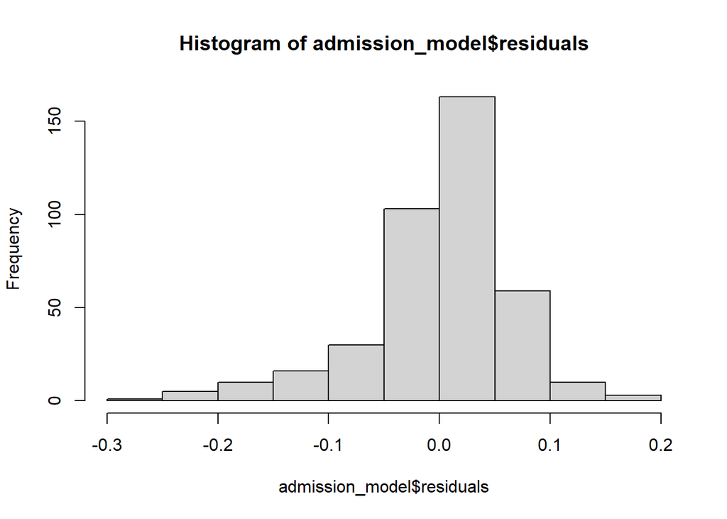

```r
hist(admission_model$residuals)
```

Our visual shows bell curve with longer tail on the left side, mean we have outlier in our data, but i decide to leave it as it is because the amount is to low, hence why we have the bell curve.

```r
shapiro.test(admission_model$residuals)
```

```
##
##  Shapiro-Wilk normality test
##
## data:  admission_model$residuals
## W = 0.92193, p-value = 0.0000000000001443
```

H1 = errors are not distributed normally

As expected, the model did not pass the stastistical test.

## Homoscedasticity

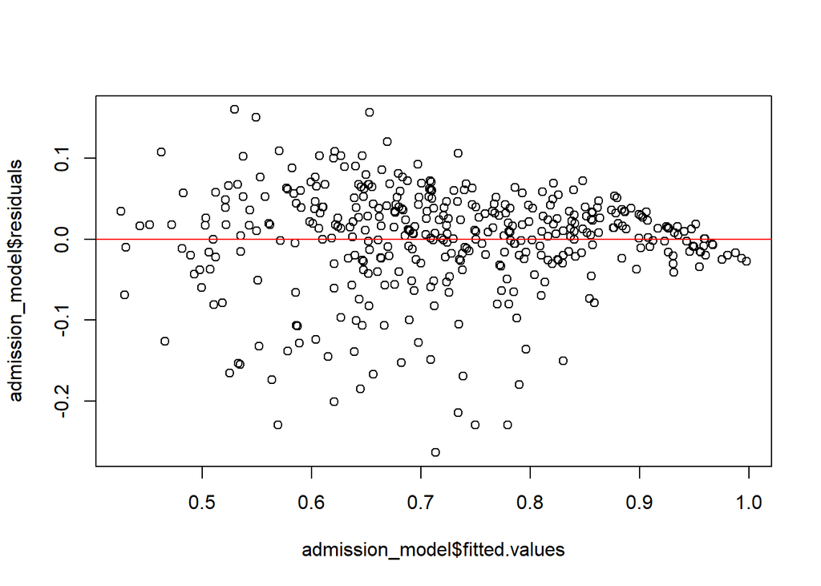

```r
plot(admission_model$fitted.values, admission_model$residuals)
abline(h = 0, col = 'red')
```

```r
bptest(admission_model)
```

```
##
##  studentized Breusch-Pagan test
##
## data:  admission_model
## BP = 22.428, df = 5, p-value = 0.0004341
```

With p-value < 0.05, we can conclude that heterocesdasticity is present. Our model did not pass Homoscedasticity test due to the outlier.

however, just like our normality test, our visual did not catch a pattern. visually, it pass the test.

## Multi Colinearity

```r
vif(admission_model)
```

```
##   GRE.Score TOEFL.Score         LOR        CGPA    Research
##    4.585053    4.104255    1.829491    4.808767    1.530007
```

no colinearity found.

The model violate Normality and Homoscedasticity assumption test.

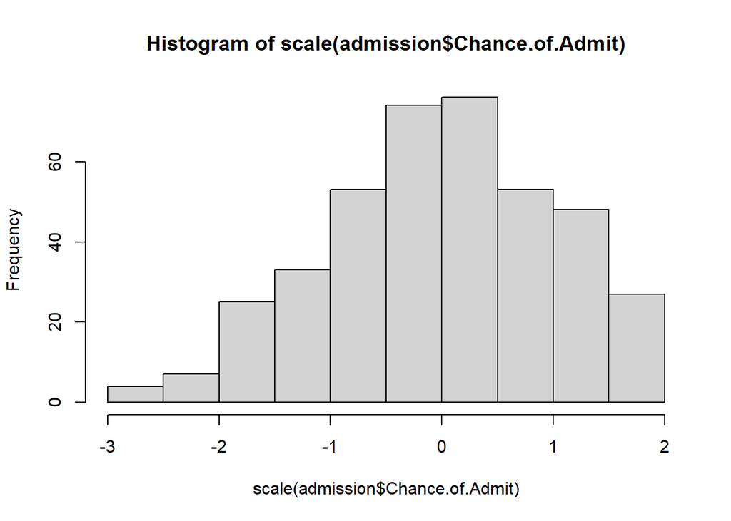

```r
hist(scale(admission$Chance.of.Admit))
```

# Evaluation

```r
test <- read.csv('AdmissionTest.csv')
```

```r
test$prediction <- predict(admission_model, newdata = test)
```

## MAPE Train and Test

```r
# MAPE TRAIN
MAPE(y_pred = admission_model$fitted.values, y_true=admission$Chance.of.Admit)
```

```
## [1] 0.07317295
```

```r
# MAPE TEST
MAPE(y_pred = test$prediction, y_true=test$Chance.of.Admit)
```

```
## [1] 0.05130283
```

## RMSE

```r
# RMSE TRAIN
RMSE(y_pred = admission_model$fitted.values, y_true=admission$Chance.of.Admit)
```

```
## [1] 0.06326207
```

```r
# RMSE TRAIN
RMSE(y_pred = test$prediction, y_true=test$Chance.of.Admit)
```

```
## [1] 0.04304102
```

Error Value are very close and even less, we can assume that the predictions are very very close to the actual value.

#Conclusion and Recommendation

Conclussion : Our model is a good-fit (Adj.R-Square = 0.8) Train and Test error value are small, and its close to each other.

Recommendation : Student who are planning to continue their study should work hard to get highest GPA possible(0-10), did a research and then try to acquire a strong letter of recomendatio, folllowed by TOELF Score and GRE Score to boost your chance of admission.

```r
admission_model$coefficients
```

```
##  (Intercept)    GRE.Score  TOEFL.Score          LOR         CGPA     Research
## -1.298463648  0.001782011  0.003031957  0.022776188  0.121004204  0.024576889
```